# datawise-03-hiearchical-clustering

## Clustering time series to identify appropriate model

Cluster the simulated series in order to identify similar subgroups. Do these subgroups correspond to the processes that generated each class of series?

Since the actual class is known because the data is simulated, we are able to evaluate whether clustering the series can bin the series into the correct bins.

Since the learned group labels are arbitrary, it is not as straightforward to calculate performance metrics as it would be for any given classifier. Evaluating the performance of the method is therefore done using cluster spillover.

```python
import tslearn
import hdbscan

# has warping path visualization functionality
import dtaidistance # only calculates euclidean distance to speed up C-code underneath by avoiding extra function calls
from dtaidistance import dtw_visualisation as dtwvis

import fastdtw
import statsmodels.api as sm
from statsmodels.tsa.arima_process import arma_generate_sample
import numpy as np
import pandas as pd
import scipy as sp
import random
import matplotlib.pyplot as plt
%matplotlib inline

from time_series_simulations import time_series_simulations
```

```python
from sklearn.neighbors import NearestNeighbors
from sklearn.neighbors import DistanceMetric
from sklearn.cluster import AgglomerativeClustering
from sklearn import metrics
```

```python
standardized_series = time_series_simulations.simulate_ts_population()
```

## Calculate pairwise distances

```python
# dtaidistance has a built in function that produces a pairwise distance matrix
# first put all the series in a list of lists
series_list = standardized_series.groupby('id')['stand_amount'].apply(np.array) # returns a series
series_list = [np.array(x) for x in series_list] # cast series into a list of np.arrays
print(series_list[0])
```

```
[-8.39404400e-01  4.00717900e-01  8.83818029e-01 -1.63355742e+00
  3.03049133e-01 -8.12994799e-01  2.85147714e-01  8.08078047e-01
  8.75225412e-01 -3.19349645e-02 -2.58654159e-01  4.89814812e-01
 -6.99712577e-01  4.55648788e-01 -1.55269235e+00  1.62905045e-02
  1.42565256e+00  3.30615182e-01  2.76149384e-01  1.40568324e-03
  1.56322347e+00  7.99132741e-01  1.24966782e+00 -6.70210562e-01
 -1.32291771e+00  3.41407857e-01 -1.01982651e+00  2.97775032e-01
  6.79880532e-02  4.73664892e-01 -1.27070665e+00 -7.20973260e-01
 -9.29476841e-01 -1.94918698e+00 -3.98999712e-01  4.16798811e-01
 -1.51931335e+00 -1.49293005e+00 -7.64300182e-01 -1.86299765e+00
 -4.63805966e-01  9.58694289e-02  6.28338170e-01 -1.64121245e+00
  1.47933190e-01  1.56185675e-01  2.25181276e+00  1.63101806e+00
 -3.71131831e-01  1.65694447e-01 -7.85601468e-01 -7.92222426e-01
  1.29001642e+00  7.84594482e-01  2.63605953e-01  1.45201913e+00
 -3.91745594e-01 -4.23999722e-01  1.05224875e+00  4.60444709e-01
  2.47945658e+00]
```

```python
# then calculate the matrix
distance_matrix = dtaidistance.dtw.distance_matrix_fast(series_list)
```

```python
# alternatively, here is my code to do the pairwise calculations without a library
# this is probably slower than dtaidistance.dtw.distance_matrix_fast
# create an empty square dataframe to populate with distances
# n_accounts = len(np.unique(standardized_series['id']))
# pairwise_dtw = pd.DataFrame(np.zeros([n_accounts, n_accounts]))
```

```python
# n_accounts
```

```python
# # get the iterable
# the_ids = standardized_series['id']

# # loop through the iterable
# for i, id1 in enumerate(the_ids):
#     for j, id2 in enumerate(the_ids): # only populate top half
#         # get the accounts' time series
#         ts_one = standardized_series.loc[standardized_series['id'] == id1, ['timepoint', 'amount']]
#         ts_two = standardized_series.loc[standardized_series['id'] == id2, ['timepoint', 'amount']]

#         # calculate Manhattan distance
#         pairwise_dtw.loc[i,j] = fastdtw.fastdtw(ts_one, ts_two, dist=1)[0]
#         print(i,id1, "\t",j, id2)

#         # calculate Euclidean distance
#         #pairwise_dtw.loc[i,j] = dtaidistance.dtw.distance(ts_one['amount'], ts_two['amount'])
```

#### Set up the simulated series in the wide format for clustering

```python
# TODO fix this if necessary, use the series_list above as a starting point
## clustering wants the data in the wide format
# n_rows = len([element for sim_list in all_series for element in sim_list])

# all_series_wide = pd.DataFrame(index = range(0, n_rows), columns = ['id', 'timepoint', 'amount', 'process'])

# for index in range(0, len(all_series)):
#     all_series_wide.at[index, 'id'] = index
#     all_series_wide.at[index, 'timepoint'] = list(range(0, len(all_series[index])))
#     all_series_wide.at[index, 'amount'] = list(all_series[index])
#     all_series_wide.at[index, 'process'] =
```

```python
# sim_series_wide.head()
```

As an alternative to warped paths, I could align in time and then calculate Euclidean distance timepoint by timepoint. This would be more appropriate if the series have seasonality - perhaps. It's also possible that if the series do have seasonality, they are offset relative to each other, for example in the case where winter-related products are relevant during different parts of the year e.g. Nov vs Jan.

### Cluster

Two options:

1. Use a supervised method by training a 1-NN classifier that uses DTW distances, 5-fold cross validation (based on sample size of 100) and simulated data so that the observations (time series) have labels (the process from which they were simulated eg. ARMA(1,1)). Hold out some of the simulated data to use as the test set, this represents the unlabeled "real" data.

   1-nn and dtw is difficult to beat for time series classification, and for a good summary of approaches taken towards time series classification including neural networks (predictive modular NNs, and a combination of HMM and ANNs) (page 83) [Mitsa et al 2010 Temporal Data Mining chapter on Temporal Classification](https://books.google.com/books?id=4P_7ydvW7cAC&pg=PA67&source=gbs_toc_r&cad=3#v=onepage&q&f=false)

   A time series can be represented by a feature vector made up of the Fourier transform coefficients of the time series, and its mean, skewness, and kurtosis. This feature vector can be used as input to a clustering algorithm.

   Also see [this paper](https://arxiv.org/pdf/1406.4757.pdf)
2. Alternatively, use hierarchical clustering to identify groups of similar time series in an unsupervised way. The hope would be for time series generated by the same process, e.g. an ARMA(1,1) to be more similar to each other than to those generated by other processes, e.g. a MA(2).

### With dtaidistance clustering

```python
from dtaidistance import clustering
from numpy import inf
```

```python
# change inf to zeros
distance_matrix[distance_matrix == inf] = 0
```

```python
distance_matrix
```

```
array([[ 0.        ,  3.03565278,  7.69467613, ...,  7.95736495,
         4.19557141,  8.77425141],
       [ 0.        ,  0.        ,  7.28726145, ...,  8.49846915,
         4.6712978 ,  8.75798967],
       [ 0.        ,  0.        ,  0.        , ...,  7.32269003,
         7.86299302, 13.05793635],
       ...,
       [ 0.        ,  0.        ,  0.        , ...,  0.        ,
         8.28089523, 14.88145655],
       [ 0.        ,  0.        ,  0.        , ...,  0.        ,
         0.        ,  9.0106436 ],
       [ 0.        ,  0.        ,  0.        , ...,  0.        ,
         0.        ,  0.        ]])
```

```python
# expected size is square, equal to the number of unique ids
distance_matrix.shape
```

```
(1400, 1400)
```

```python
# # computes the distance matrix first
# model = dtaidistance.clustering.Hierarchical(dtaidistance.dtw.distance_matrix_fast, {})
# model2 = dtaidistance.clustering.HierarchicalTree(model)
# cluster_idx = model2.fit(distance_matrix)
```

### Hierarchical clustering with sklearn

#### Learn clusters for each time series

```python
standardized_series.head()
```

|  | id | timepoint | amount | stand_amount | process |
| --- | --- | --- | --- | --- | --- |
| 0 | 0ar1 | 0 | -0.650442 | -0.839404 | ar1 |
| 1 | 0ar1 | 1 | 0.704786 | 0.400718 | ar1 |
| 2 | 0ar1 | 2 | 1.232727 | 0.883818 | ar1 |
| 3 | 0ar1 | 3 | -1.518306 | -1.633557 | ar1 |
| 4 | 0ar1 | 4 | 0.598052 | 0.303049 | ar1 |

```python
print(standardized_series.shape)
```

```
(155888, 5)
```

```python
standardized_series['process'].value_counts()
```

```
arima112    11911
arma12      11706
arima111    11579
ar2         11478
arima222    11367
ma2         11189
arima211    11163
arima011    11144
ma1         11117
arma11      11057
arma21      10752
ar1         10749
arima110    10392
arma22      10284
Name: process, dtype: int64
```

```python
# cluster on the distance matrix
n_clusters = len(np.unique(list(standardized_series['process']))) # use the real number of clusters
hclust = AgglomerativeClustering(n_clusters = n_clusters, affinity='precomputed', linkage = 'average')
clusters = hclust.fit(distance_matrix)
```

```python
# get a frequency table of the labels
# np.bincount(clusters.labels_)
np.unique(clusters.labels_, return_counts=True)
```

```
(array([ 0,  1,  2,  3,  4,  5,  6,  7,  8,  9, 10, 11, 12, 13]),
 array([247, 102,   6,   5,  47,  20, 118, 536,  40,   7,   2,   6, 229,
         35]))
```

```python
# evaluate the clusters
# do they separate the processes?

# merge in the ids for the learned labels
membership = pd.DataFrame({"id": standardized_series['id'].unique(), "hier_cluster": clusters.labels_})
```

```python
membership.head()
```

|  | id | hier_cluster |
| --- | --- | --- |
| 0 | 0ar1 | 0 |
| 1 | 0ar2 | 0 |
| 2 | 0arima011 | 7 |
| 3 | 0arima110 | 7 |
| 4 | 0arima111 | 7 |

```python
# merge with the actual process labels to evaluate
standardized_series = standardized_series.merge(membership, left_on="id", right_on="id")
```

```python
standardized_series.head()
```

|  | id | timepoint | amount | stand_amount | process | hier_cluster |
| --- | --- | --- | --- | --- | --- | --- |
| 0 | 0ar1 | 0 | -0.650442 | -0.839404 | ar1 | 0 |
| 1 | 0ar1 | 1 | 0.704786 | 0.400718 | ar1 | 0 |
| 2 | 0ar1 | 2 | 1.232727 | 0.883818 | ar1 | 0 |
| 3 | 0ar1 | 3 | -1.518306 | -1.633557 | ar1 | 0 |
| 4 | 0ar1 | 4 | 0.598052 | 0.303049 | ar1 | 0 |

```python
# drop the length of the series, keep just one record per time series
# to compare real label with learned label
per_id = standardized_series[standardized_series['timepoint'] == 0]
```

```python
per_id = per_id.drop(['timepoint', 'amount', 'stand_amount'], axis = 1)
```

```python
per_id.head()
```

|  | id | process | hier_cluster |
| --- | --- | --- | --- |
| 0 | 0ar1 | ar1 | 0 |
| 61 | 0ar2 | ar2 | 0 |
| 124 | 0arima011 | arima011 | 7 |
| 261 | 0arima110 | arima110 | 7 |
| 373 | 0arima111 | arima111 | 7 |

```python
# collect the above developed code in a function
def assign_to_clusters(standardized_series, hclust_obj, col_name):
    '''Assumes a distance matrix called "distance_matrix" exists in the environment.

    Keyword arguments:
    standardized_series : simulated series dataframe, each row is a timepoint
    hclust_obj : hierarchical clustering object from sklearn AgglomerativeClustering() method
    col_name : name for the new column that holds the predicted cluster membership for each observation'''

    # cluster on the distance matrix
    clusters = hclust_obj.fit(distance_matrix)

    # merge in the ids for the learned labels
    membership = pd.DataFrame({"id": standardized_series['id'].unique(), col_name: clusters.labels_})

    # merge with the actual process labels to evaluate
    merged = standardized_series.merge(membership, left_on="id", right_on="id")

    # drop the length of the series, keep just one record per time series
    # to compare real label with learned label
    per_obs_clusters = merged[merged['timepoint'] == 0]
    per_obs_clusters = per_obs_clusters.drop(['timepoint', 'amount', 'stand_amount'], axis = 1)

    return per_obs_clusters
```

#### Quantitative evaluation of cluster quality

Calculate contingency table.

```python
# to evaluate cluster quality calculate performance metrics (purity etc)
# hier_cluster is equivalent to y_pred (following sklearn metrics nomenclature)
# need to convert the true labels, y_true, i.e. the column "process", into the 0-13 cluster labels to evaluate cluster quality
# first assign the predicted cluster to the actual cluster with the highest frequency in the predicted cluster

# subset to the predicted cluster
cluster_0 = per_id[per_id['hier_cluster'] == 0]
# cast into dataframe to find max frequency and retrieve the corresponding process
df = pd.DataFrame(cluster_0['process'].value_counts()).reset_index()
assumed_cluster = df[df['process'] == df['process'].max()]['index'][0]
```

```python
assumed_cluster
```

```
'ar1'
```

```python
# assigns true positives as True
# False in this column is a mix of false positives, false negatives and true negatives
TP = sum((per_id['process'] == assumed_cluster) & (per_id['hier_cluster'] == 0))
```

```python
# assigns true negatives
TN = sum((per_id['process'] != assumed_cluster) & (per_id['hier_cluster'] != 0))

# assigns false positives
# predicted true but actually something else
FP = sum((per_id['process'] != assumed_cluster) & (per_id['hier_cluster'] == 0))

# assigns false negatives
# predicted false but actually true
FN = sum((per_id['process'] == assumed_cluster) & (per_id['hier_cluster'] != 0))
```

```python
contingency_table = np.array([[TP, TN], [FP, FN]])
```

```python
contingency_table
```

```
array([[  35, 1088],
       [ 212,   65]])
```

```python
# sum correctly classified (TN and TP) and divide by the N
purity_cluster_0 = np.sum(np.amax(contingency_table, axis=0)) / np.sum(contingency_table)
print(purity_cluster_0)
```

```
0.9285714285714286
```

```python
# clean up per_id dataframe
per_id = per_id.drop(columns=['TP', 'TN', 'FP', 'FN'])
```

```python
# collect into a function
# TODO: there is an easier/faster way to do this

def cluster_contingency_table(per_obs_clusters, pred_cluster):
    # subset to the predicted cluster
    pred_cluster_df = per_obs_clusters[per_obs_clusters['hier_cluster'] == pred_cluster]

    # cast into dataframe to find max frequency and retrieve the corresponding process
    df = pd.DataFrame(pred_cluster_df['process'].value_counts()).reset_index()
    assumed_cluster = df[df['process'] == df['process'].max()]['index'][0]

    # assigns true positives as True
    # False in this column is a mix of false positives, false negatives and true negatives
    TP = sum((per_obs_clusters['process'] == assumed_cluster) & (per_obs_clusters['hier_cluster'] == 0))

    # assigns true negatives
    TN = sum((per_obs_clusters['process'] != assumed_cluster) & (per_obs_clusters['hier_cluster'] != 0))

    # assigns false positives
    # predicted true but actually something else
    FP = sum((per_obs_clusters['process'] != assumed_cluster) & (per_obs_clusters['hier_cluster'] == 0))

    # assigns false negatives
    # predicted false but actually true
    FN = sum((per_obs_clusters['process'] == assumed_cluster) & (per_obs_clusters['hier_cluster'] != 0))

    # put in a contingency table
    contingency_table = np.array([[TN,FP],[FN,TP]])

    return contingency_table
```

```python
def cluster_purity(contigency_table):
    return np.sum(np.amax(contingency_table, axis=0)) / np.sum(contingency_table)
```

```python
# use the above functions iteratively on each predicted cluster
cluster_ids = np.sort(per_id['hier_cluster'].unique())
for cluster in cluster_ids:
    cont_tab = cluster_contingency_table(per_id, cluster)
    print(np.amax(cont_tab, axis=0))
    purity = cluster_purity(cont_tab)
    print("Cluster " + str(cluster) + " purity score = " + str(purity))
```

```
[1088  212]
Cluster 0 purity score = 0.9285714285714286
[1082  218]
Cluster 1 purity score = 0.9285714285714286
[1068  232]
Cluster 2 purity score = 0.9285714285714286
[1083  217]
Cluster 3 purity score = 0.9285714285714286
[1085  215]
Cluster 4 purity score = 0.9285714285714286
[1082  218]
Cluster 5 purity score = 0.9285714285714286
[1083  217]
Cluster 6 purity score = 0.9285714285714286
[1058  242]
Cluster 7 purity score = 0.9285714285714286
[1088  212]
Cluster 8 purity score = 0.9285714285714286
[1067  233]
Cluster 9 purity score = 0.9285714285714286
[1078  222]
Cluster 10 purity score = 0.9285714285714286
[1083  217]
Cluster 11 purity score = 0.9285714285714286
[1067  233]
Cluster 12 purity score = 0.9285714285714286
[1088  212]
Cluster 13 purity score = 0.9285714285714286
```

They are all the same because the TN are a huge proportion of N!

```python
# create vector of y_true instead of the contingency table
# so they can be used with other metrics

# reminder: what did the df look like?
print(per_id.head(), '\n')

# reminder: what was the dominant class in the cluster?
print(assumed_cluster)
```

```
            id   process  hier_cluster
0         0ar1       ar1             0
61        0ar2       ar2             0
124  0arima011  arima011             7
261  0arima110  arima110             7
373  0arima111  arima111             7

ar1
```

```python
# create new column where ar1 is 0 and all others are a number that doesn't exist in the predicted clusters
mask = (per_id['process'] == 'ar1')
max_cluster = per_id['hier_cluster'].unique().max()
per_id['y_true'] = np.where(mask, 0, max_cluster + 1)
```

```python
# verify that it worked as intended
per_id.head(20)
```

|  | id | process | hier_cluster | y_true |
| --- | --- | --- | --- | --- |
| 0 | 0ar1 | ar1 | 0 | 0 |
| 61 | 0ar2 | ar2 | 0 | 14 |
| 124 | 0arima011 | arima011 | 7 | 14 |
| 261 | 0arima110 | arima110 | 7 | 14 |
| 373 | 0arima111 | arima111 | 7 | 14 |
| 485 | 0arima112 | arima112 | 7 | 14 |
| 521 | 0arima211 | arima211 | 12 | 14 |
| 653 | 0arima222 | arima222 | 12 | 14 |
| 828 | 0arma11 | arma11 | 4 | 14 |
| 988 | 0arma12 | arma12 | 7 | 14 |
| 1122 | 0arma21 | arma21 | 0 | 14 |
| 1178 | 0arma22 | arma22 | 0 | 14 |
| 1274 | 0ma1 | ma1 | 0 | 14 |
| 1309 | 0ma2 | ma2 | 4 | 14 |
| 1464 | 10ar1 | ar1 | 7 | 0 |
| 1637 | 10ar2 | ar2 | 0 | 14 |
| 1693 | 10arima011 | arima011 | 7 | 14 |
| 1778 | 10arima110 | arima110 | 7 | 14 |
| 1958 | 10arima111 | arima111 | 7 | 14 |
| 2050 | 10arima112 | arima112 | 7 | 14 |

```python
# collect into a function
def translate_y_true(per_obs_clusters, pred_cluster):
    # subset to the predicted cluster
    pred_cluster_df = per_obs_clusters[per_obs_clusters['hier_cluster'] == pred_cluster]

    # cast into dataframe to find max frequency and retrieve the corresponding process
    df = pd.DataFrame(pred_cluster_df['process'].value_counts()).reset_index()
    assumed_cluster = df[df['process'] == df['process'].max()]['index'][0]

    # define y_pred
    mask = (per_obs_clusters['process'] == assumed_cluster)
    max_cluster = per_obs_clusters['hier_cluster'].unique().max()
    y_true = np.where(mask, pred_cluster, max_cluster + 1)

    return y_true
```

The metrics below are calculated for cluster 0 only, since that's the one with respect to which y_pred was calculated.

```python
# cross entropy
metrics.log_loss(y_pred=per_id['hier_cluster'], y_true=per_id['y_true'])
```

```
6.833780739445159
```

```python
# Rand index
metrics.adjusted_rand_score(labels_pred=per_id['hier_cluster'], labels_true=per_id['y_true'])
```

```
0.04284958390665606
```

```python
# normalized mutual information
metrics.normalized_mutual_info_score(labels_pred=per_id['hier_cluster'], labels_true=per_id['y_true'])
```

```
0.08449424102725225
```

```python
# normalized mutual information adjusted for chance
metrics.adjusted_mutual_info_score(labels_pred=per_id['hier_cluster'], labels_true=per_id['y_true'])
```

```
0.029107782382173576
```

```python
# F measure would need the labels to be adjusted to the binary case
#metrics.f1_score(y_pred=per_id['hier_cluster'], y_true=per_id['y_true'])
```

```python
# calculate metrics
def performance(y_pred, y_true):
    rand = metrics.adjusted_rand_score(labels_pred=y_pred, labels_true=y_true)
    nmi = metrics.normalized_mutual_info_score(labels_pred=y_pred, labels_true=y_true)
    ami = metrics.adjusted_mutual_info_score(labels_pred=y_pred, labels_true=y_true)

    return rand, nmi, ami
```

```python
# define iterable
cluster_ids = np.sort(per_id['hier_cluster'].unique())

# df to hold performance metrics for each cluster
performance_df = pd.DataFrame(columns = ['cluster_id', 'rand_score', 'nmi', 'adjusted_mi'],
                              index = cluster_ids)
```

```python
# loop
for cluster in cluster_ids:
    y_true = translate_y_true(per_id, cluster)
    cluster_quality = performance(per_id['hier_cluster'], y_true)
    performance_df.loc[cluster] = pd.Series({'cluster_id': cluster,
                                                 'rand_score': cluster_quality[0],
                                                 'nmi': cluster_quality[1],
                                                 'adjusted_mi': cluster_quality[2]})
```

```python
performance_df
```

|  | cluster_id | rand_score | nmi | adjusted_mi |
| --- | --- | --- | --- | --- |
| 0 | 0 | 0.0428496 | 0.0844942 | 0.0291078 |
| 1 | 1 | 0.0372167 | 0.080396 | 0.0275714 |
| 2 | 2 | 0.025442 | 0.0590074 | 0.0195529 |
| 3 | 3 | 0.0515591 | 0.111501 | 0.0392323 |
| 4 | 4 | 0.0535833 | 0.136464 | 0.0485909 |
| 5 | 5 | 0.0372167 | 0.080396 | 0.0275714 |
| 6 | 6 | 0.0515591 | 0.111501 | 0.0392323 |
| 7 | 7 | -0.0422565 | 0.088633 | 0.0306594 |
| 8 | 8 | 0.0428496 | 0.0844942 | 0.0291078 |
| 9 | 9 | 0.0303636 | 0.0678914 | 0.0228834 |
| 10 | 10 | 0.0168019 | 0.0426475 | 0.0134197 |
| 11 | 11 | 0.0515591 | 0.111501 | 0.0392323 |
| 12 | 12 | 0.0303636 | 0.0678914 | 0.0228834 |
| 13 | 13 | 0.0428496 | 0.0844942 | 0.0291078 |

```
Text(0,0.5,'Adjusted Rand score')
```

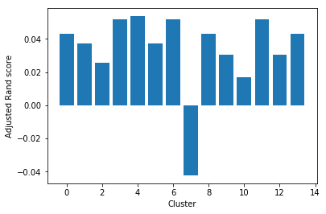

```python
plt.bar(performance_df['cluster_id'], performance_df['rand_score'])
plt.xlabel('Cluster')
plt.ylabel('Adjusted Rand score')
```

```
Text(0,0.5,'Normalized mutual information')
```

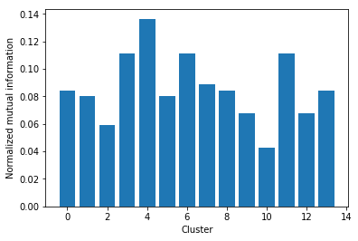

```python
plt.bar(performance_df['cluster_id'], performance_df['nmi'])
plt.xlabel('Cluster')
plt.ylabel('Normalized mutual information')
```

```
Text(0,0.5,'Adjusted normalized mutual information')
```

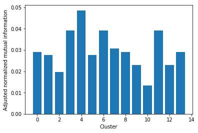

```python
plt.bar(performance_df['cluster_id'], performance_df['adjusted_mi'])
plt.xlabel('Cluster')
plt.ylabel('Adjusted normalized mutual information')
```

#### Qualitative evaluation of cluster quality

Need to reshape the results to visualize cluster quality using a bar chart for each class.

```python
# to visualize the results, put in a different format
# count how many distinct ids have each (actual process & learned process) pair
results = per_id.groupby(['process', 'hier_cluster']).count()
```

```python
results = pd.DataFrame(results).reset_index()
```

```python
# the column id now shows the count of time series that were in class "process" (true label)
# and clustered into "hier_cluster" (learned label)
results = results.rename(columns = {'id': 'count'})
results.head()
```

|  | process | hier_cluster | count |
| --- | --- | --- | --- |
| 0 | ar1 | 0 | 35 |
| 1 | ar1 | 1 | 12 |
| 2 | ar1 | 4 | 3 |
| 3 | ar1 | 5 | 1 |
| 4 | ar1 | 6 | 17 |

```python
# reshape so that all processes have all clusters represented in the dataframe, even if the counts are zero
results = results.pivot(index='process', columns='hier_cluster', values='count')
results.head()
```

| hier_cluster process | 0 | 1 | 2 | 3 | 4 | 5 | 6 | 7 | 8 | 9 | 10 | 11 | 12 | 13 |
| --- | --- | --- | --- | --- | --- | --- | --- | --- | --- | --- | --- | --- | --- | --- |
| ar1 | 35.0 | 12.0 | NaN | NaN | 3.0 | 1.0 | 17.0 | 5.0 | 14.0 | NaN | NaN | NaN | NaN | 13.0 |
| ar2 | 14.0 | 2.0 | 3.0 | NaN | 1.0 | 1.0 | 7.0 | 8.0 | 4.0 | 5.0 | NaN | NaN | 52.0 | 3.0 |
| arima011 | 7.0 | NaN | NaN | NaN | NaN | NaN | NaN | 93.0 | NaN | NaN | NaN | NaN | NaN | NaN |
| arima110 | 9.0 | NaN | NaN | NaN | NaN | NaN | NaN | 91.0 | NaN | NaN | NaN | NaN | NaN | NaN |
| arima111 | 10.0 | NaN | NaN | NaN | NaN | NaN | NaN | 90.0 | NaN | NaN | NaN | NaN | NaN | NaN |

```python
results = results.fillna(0)
results
```

| hier_cluster process | 0 | 1 | 2 | 3 | 4 | 5 | 6 | 7 | 8 | 9 | 10 | 11 | 12 | 13 |
| --- | --- | --- | --- | --- | --- | --- | --- | --- | --- | --- | --- | --- | --- | --- |
| ar1 | 35.0 | 12.0 | 0.0 | 0.0 | 3.0 | 1.0 | 17.0 | 5.0 | 14.0 | 0.0 | 0.0 | 0.0 | 0.0 | 13.0 |
| ar2 | 14.0 | 2.0 | 3.0 | 0.0 | 1.0 | 1.0 | 7.0 | 8.0 | 4.0 | 5.0 | 0.0 | 0.0 | 52.0 | 3.0 |
| arima011 | 7.0 | 0.0 | 0.0 | 0.0 | 0.0 | 0.0 | 0.0 | 93.0 | 0.0 | 0.0 | 0.0 | 0.0 | 0.0 | 0.0 |
| arima110 | 9.0 | 0.0 | 0.0 | 0.0 | 0.0 | 0.0 | 0.0 | 91.0 | 0.0 | 0.0 | 0.0 | 0.0 | 0.0 | 0.0 |
| arima111 | 10.0 | 0.0 | 0.0 | 0.0 | 0.0 | 0.0 | 0.0 | 90.0 | 0.0 | 0.0 | 0.0 | 0.0 | 0.0 | 0.0 |
| arima112 | 5.0 | 0.0 | 0.0 | 0.0 | 0.0 | 0.0 | 0.0 | 95.0 | 0.0 | 0.0 | 0.0 | 0.0 | 0.0 | 0.0 |
| arima211 | 3.0 | 0.0 | 0.0 | 0.0 | 0.0 | 0.0 | 0.0 | 52.0 | 0.0 | 0.0 | 0.0 | 0.0 | 45.0 | 0.0 |
| arima222 | 0.0 | 0.0 | 0.0 | 0.0 | 0.0 | 0.0 | 0.0 | 56.0 | 0.0 | 0.0 | 0.0 | 0.0 | 44.0 | 0.0 |
| arma11 | 33.0 | 21.0 | 0.0 | 0.0 | 10.0 | 3.0 | 19.0 | 10.0 | 2.0 | 0.0 | 1.0 | 0.0 | 0.0 | 1.0 |
| arma12 | 29.0 | 33.0 | 0.0 | 0.0 | 3.0 | 8.0 | 14.0 | 10.0 | 1.0 | 0.0 | 0.0 | 1.0 | 0.0 | 1.0 |
| arma21 | 15.0 | 14.0 | 3.0 | 0.0 | 2.0 | 0.0 | 6.0 | 10.0 | 0.0 | 0.0 | 0.0 | 0.0 | 50.0 | 0.0 |
| arma22 | 25.0 | 12.0 | 0.0 | 2.0 | 0.0 | 0.0 | 4.0 | 16.0 | 0.0 | 2.0 | 1.0 | 0.0 | 38.0 | 0.0 |
| ma1 | 32.0 | 0.0 | 0.0 | 0.0 | 22.0 | 0.0 | 19.0 | 0.0 | 14.0 | 0.0 | 0.0 | 0.0 | 0.0 | 13.0 |
| ma2 | 30.0 | 8.0 | 0.0 | 3.0 | 6.0 | 7.0 | 32.0 | 0.0 | 5.0 | 0.0 | 0.0 | 5.0 | 0.0 | 4.0 |

```python
# collect into a function
def reshape_to_plot(per_obs_clusters):

    # count how many distinct ids have each (actual process & learned process) pair
    results = per_obs_clusters.groupby(['process', col_name]).count()
    results = pd.DataFrame(results).reset_index()
    # the column id now shows the count of time series that were in class "process" (true label)
    # and clustered into "hier_cluster" (learned label)
    results = results.rename(columns = {'id': 'count'})
    # reshape so that all processes have all clusters represented in the dataframe, even if the counts are zero
    results = results.pivot(index='process', columns=col_name, values='count')
    results = results.fillna(0)

    return results
```

```python
# for each actual process, plot the distribution across the learned processes
def plot_cluster(process_name, results_object):
    plot1 = plt.bar(results_object.columns, results_object.loc[process_name])
    plt.title(process_name + '\n(total count = 100)')
    plt.xlabel('Cluster')
    plt.ylabel('Count')
    plt.ylim(0, 100)
```

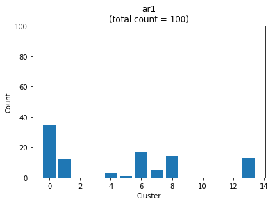

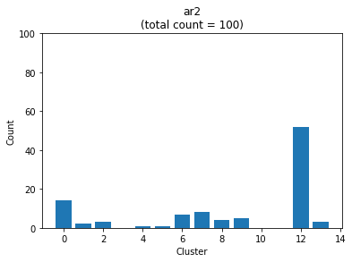

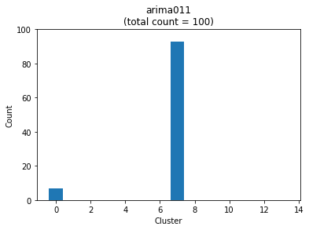

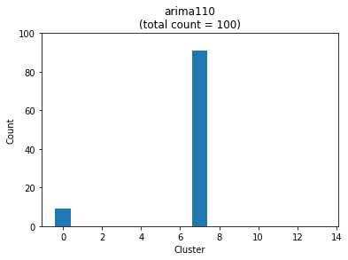

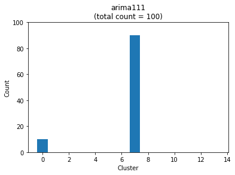

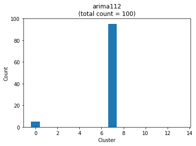

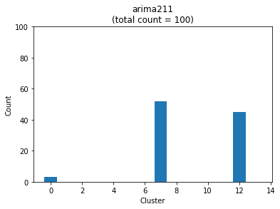

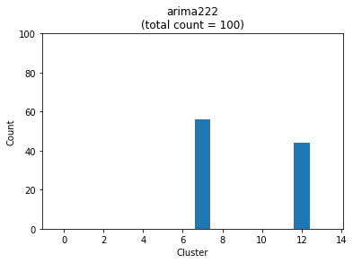

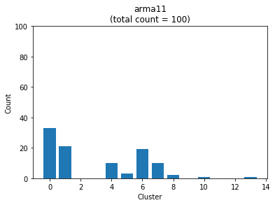

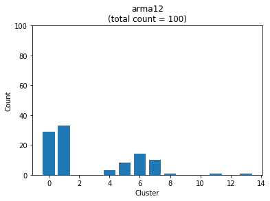

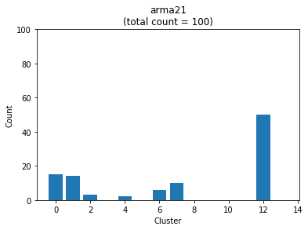

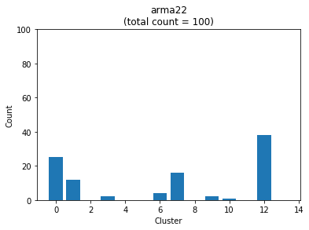

[2 more figures not shown]

```python
for index, process in enumerate(results.index):
    plt.figure(index)
    plot_cluster(process, results)
```

Observations:

#### Try other linkage functions

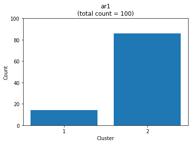

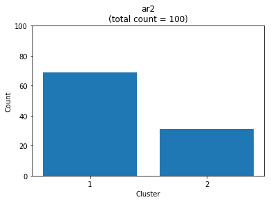

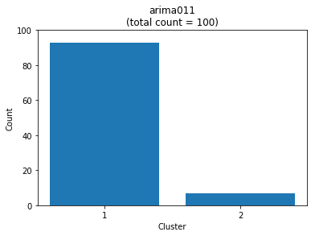

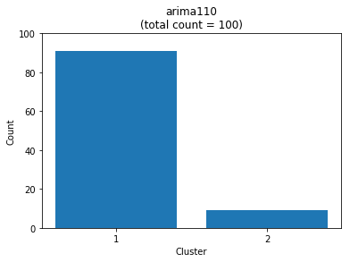

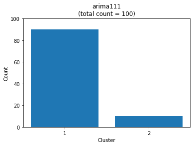

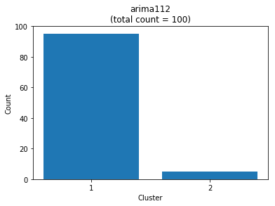

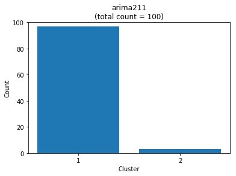

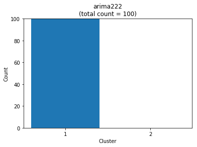

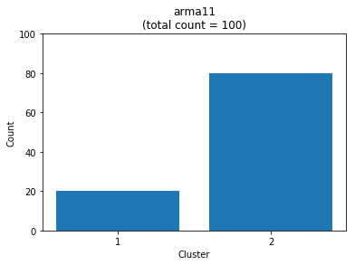

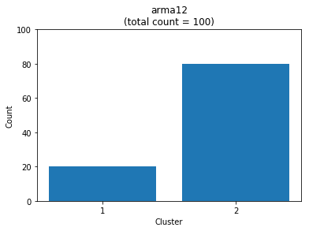

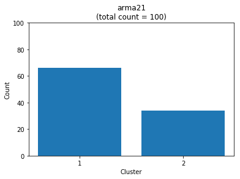

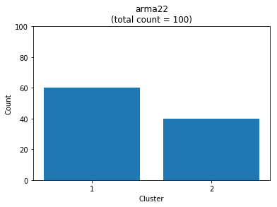

[2 more figures not shown]

```python
# complete linkage with no n_cluster parameter specification
complete_hclust = AgglomerativeClustering(affinity='precomputed', linkage = 'complete')

complete_results = cluster_and_compare(standardized_series, complete_hclust, 'complete_linkage_cluster')

complete_results.columns = ['1', '2']

for index, process in enumerate(complete_results.index):
    plt.figure(index)
    plot_cluster(process, complete_results)
```

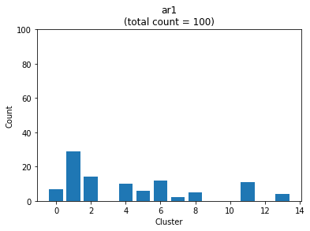

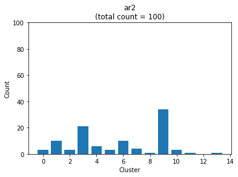

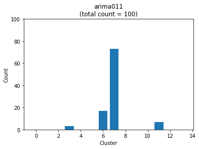

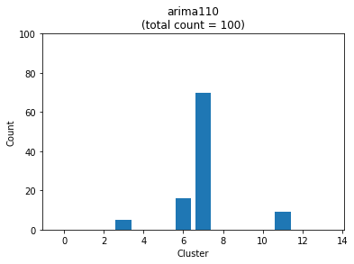

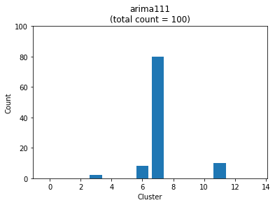

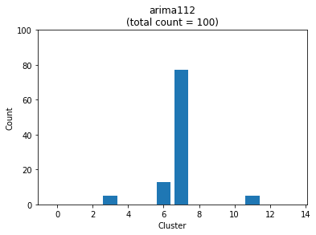

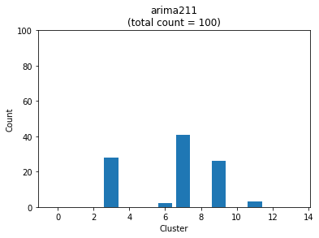

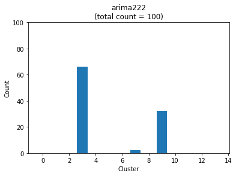

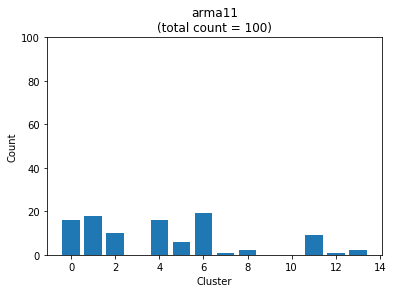

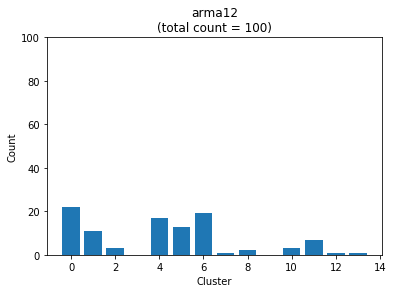

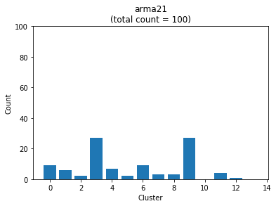

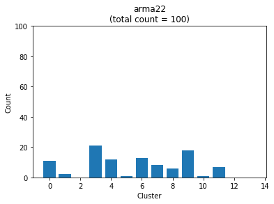

[2 more figures not shown]

```python
# complete linkage with n_clusters = 14 parameter specification
n_clusters = len(np.unique(list(standardized_series['process']))) # use the real number of clusters
complete_hclust_14 = AgglomerativeClustering(n_clusters, affinity='precomputed', linkage = 'complete')

complete_14_results = cluster_and_compare(standardized_series, complete_hclust_14, 'complete_14_cluster')

for index, process in enumerate(complete_14_results.index):
    plt.figure(index)
    plot_cluster(process, complete_14_results)
```

### Hierarchical clustering plus dendrogram

```python
# # with scipy
# scipy_hclust = linkage(pairwise_dtw, 'average')
# fig = plt.figure(figsize=(25, 10))
# dendro = dendrogram(hclust)
```

```python
# scipy_hclust # what do these represent?
```

```python
# # get cluster labels
# results = dendrogram(scipy_hclust,
#                     truncate_mode = 'lastp',  # show only the last p merged clusters
#                     p = 4, # show only the last 4 merged clusters
#                     no_plot = True) # returns the dictionary that contains the labels instead of the plot
```

```python
# results
```

```python
# fcluster(hclust, criterion='distance') # get cluster labels
```

```python
# try to decompose the series and cluster only the trend components in an attempt to reduce the noise?
# or go with the supervised classification approach
# or ARMA processes are too similar to each other to tease apart the p and q parameters based on the geometry of the series - add ARCH/GARCH processes to the mix to see
```

```python
# # use custom distance metric
# dtw_metric = DistanceMetric.get_metric('pyfunc', func = fastdtw(dist = 1))
# # 1-NN
# knn = NearestNeighbors(n_neighbors = 1, radius = 0.5)#, metric = dtw_metric)
# knn.fit(sim_series)
```